# TimeSeries

```python
import matplotlib.pyplot as plt
import numpy as np
import pandas as pd
from scipy import stats
%matplotlib inline
from collections import defaultdict
```

```python
df = pd.read_csv('ConstructionTimeSeriesDataV2.csv')
print(df)
xx = list(df['Public Construction'])
yy = defaultdict(list)
zz = []
opc = []
for i in xx:
    yy[xx.index(i)%12].append(i)
for i in yy.values():
    zz.append(i)
for i in zz:
    for j in i:
        opc.append(j)
df['Ordered Public Construction'] = opc
xx = list(df['Private Construction'])
yy = defaultdict(list)
zz = []
opc = []
for i in xx:
    yy[xx.index(i)%12].append(i)
for i in yy.values():
    zz.append(i)
for i in zz:
    for j in i:
        opc.append(j)
df['Ordered Private Construction'] = opc
```

```
     Month Month-Year  Total Construction  Private Construction  \
0        1      2-Jan               59516                 45273
1        2      2-Feb               58588                 44475
2        3      2-Mar               63782                 49396
3        4      2-Apr               69504                 53283
4        5      2-May               73384                 55009
5        6      2-Jun               77182                 57801
6        7      2-Jul               78863                 58494
7        8      2-Aug               79460                 57953
8        9      2-Sep               76542                 55157
9       10      2-Oct               75710                 56023
10      11      2-Nov               71362                 53552
11      12      2-Dec               63984                 48023
12      13      3-Jan               59877                 45473
13      14      3-Feb               58526                 44620
```

[output cut: 301 more lines]

*reorder the data based on day-month format*

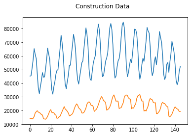

```python
fig, ax = plt.subplots()
fig.suptitle('Construction Data')
ax.plot(df['Ordered Private Construction'])
ax.plot(df['Ordered Public Construction'])
```

*plot the data for visualization*

```python
slope, intercept, r_value, p_value, std_err = stats.linregress(df.index, df['Public Construction'])
tmp = []
for i in range(len(df['Ordered Public Construction'])):
    tmp.append(float(intercept) + i * slope)

df['regress'] = tmp
df['R1Public'] = df['Ordered Public Construction'] - df['regress']
df.style.format({
    'Ordered Public Construction': '{:,.0f}'.format,
    'regress': '{:,.0f}'.format,
    'R1Public': '{:,.0f}'.format
})
```

|  | Month | Month-Year | Total Construction | Private Construction | Public Construction | Unnamed: 5 | Unnamed: 6 | Unnamed: 7 | Unnamed: 8 | Unnamed: 9 | Unnamed: 10 | Unnamed: 11 | Unnamed: 12 | Unnamed: 13 | Unnamed: 14 | Unnamed: 15 | Unnamed: 16 | Unnamed: 17 | Unnamed: 18 | Unnamed: 19 | Unnamed: 20 | Unnamed: 21 | Unnamed: 22 | Unnamed: 23 | Ordered Public Construction | Ordered Private Construction | regress | R1Public |
| --- | --- | --- | --- | --- | --- | --- | --- | --- | --- | --- | --- | --- | --- | --- | --- | --- | --- | --- | --- | --- | --- | --- | --- | --- | --- | --- | --- | --- |
| 0 | 1 | 2-Jan | 59516 | 45273 | 14243 | nan | nan | nan | nan | nan | nan | nan | nan | nan | nan | nan | nan | nan | nan | nan | nan | nan | nan | nan | 14,243 | 45273 | 18,328 | -4,085 |
| 1 | 2 | 2-Feb | 58588 | 44475 | 14113 | nan | nan | nan | nan | nan | nan | nan | nan | nan | nan | nan | nan | nan | nan | nan | nan | nan | nan | nan | 14,404 | 45473 | 18,380 | -3,976 |
| 2 | 3 | 2-Mar | 63782 | 49396 | 14386 | nan | nan | nan | nan | nan | nan | nan | nan | nan | nan | nan | nan | nan | nan | nan | nan | nan | nan | nan | 13,959 | 50975 | 18,432 | -4,473 |
| 3 | 4 | 2-Apr | 69504 | 53283 | 16221 | nan | nan | nan | nan | nan | nan | nan | nan | nan | nan | nan | nan | nan | nan | nan | nan | nan | nan | nan | 14,380 | 57094 | 18,484 | -4,104 |
| 4 | 5 | 2-May | 73384 | 55009 | 18375 | nan | nan | nan | nan | nan | nan | nan | nan | nan | nan | nan | nan | nan | nan | nan | nan | nan | nan | nan | 15,719 | 65339 | 18,536 | -2,817 |
| 5 | 6 | 2-Jun | 77182 | 57801 | 19381 | nan | nan | nan | nan | nan | nan | nan | nan | nan | nan | nan | nan | nan | nan | nan | nan | nan | nan | nan | 18,245 | 61161 | 18,588 | -343 |
| 6 | 7 | 2-Jul | 78863 | 58494 | 20369 | nan | nan | nan | nan | nan | nan | nan | nan | nan | nan | nan | nan | nan | nan | nan | nan | nan | nan | nan | 19,199 | 58150 | 18,640 | 559 |
| 7 | 8 | 2-Aug | 79460 | 57953 | 21507 | nan | nan | nan | nan | nan | nan | nan | nan | nan | nan | nan | nan | nan | nan | nan | nan | nan | nan | nan | 19,971 | 46974 | 18,692 | 1,279 |
| 8 | 9 | 2-Sep | 76542 | 55157 | 21385 | nan | nan | nan | nan | nan | nan | nan | nan | nan | nan | nan | nan | nan | nan | nan | nan | nan | nan | nan | 18,936 | 36650 | 18,744 | 192 |
| 9 | 10 | 2-Oct | 75710 | 56023 | 19687 | nan | nan | nan | nan | nan | nan | nan | nan | nan | nan | nan | nan | nan | nan | nan | nan | nan | nan | nan | 18,578 | 32377 | 18,796 | -218 |
| 10 | 11 | 2-Nov | 71362 | 53552 | 17810 | nan | nan | nan | nan | nan | nan | nan | nan | nan | nan | nan | nan | nan | nan | nan | nan | nan | nan | nan | 18,059 | 37611 | 18,848 | -789 |
| 11 | 12 | 2-Dec | 63984 | 48023 | 15961 | nan | nan | nan | nan | nan | nan | nan | nan | nan | nan | nan | nan | nan | nan | nan | nan | nan | nan | nan | 17,074 | 42070 | 18,900 | -1,826 |
| 12 | 13 | 3-Jan | 59877 | 45473 | 14404 | nan | nan | nan | nan | nan | nan | nan | nan | nan | nan | nan | nan | nan | nan | nan | nan | nan | nan | nan | 16,834 | 47827 | 18,952 | -2,118 |
| 13 | 14 | 3-Feb | 58526 | 44620 | 13906 | nan | nan | nan | nan | nan | nan | nan | nan | nan | nan | nan | nan | nan | nan | nan | nan | nan | nan | nan | 14,113 | 44475 | 19,004 | -4,891 |
| 14 | 15 | 3-Mar | 64506 | 49996 | 14510 | nan | nan | nan | nan | nan | nan | nan | nan | nan | nan | nan | nan | nan | nan | nan | nan | nan | nan | nan | 13,906 | 44620 | 19,056 | -5,150 |
| 15 | 16 | 3-Apr | 69638 | 53195 | 16444 | nan | nan | nan | nan | nan | nan | nan | nan | nan | nan | nan | nan | nan | nan | nan | nan | nan | nan | nan | 13,689 | 50449 | 19,108 | -5,419 |
| 16 | 17 | 3-May | 74473 | 56286 | 18187 | nan | nan | nan | nan | nan | nan | nan | nan | nan | nan | nan | nan | nan | nan | nan | nan | nan | nan | nan | 14,517 | 57531 | 19,160 | -4,643 |
| 17 | 18 | 3-Jun | 80377 | 60076 | 20301 | nan | nan | nan | nan | nan | nan | nan | nan | nan | nan | nan | nan | nan | nan | nan | nan | nan | nan | nan | 15,857 | 65622 | 19,212 | -3,355 |
| 18 | 19 | 3-Jul | 82971 | 62216 | 20755 | nan | nan | nan | nan | nan | nan | nan | nan | nan | nan | nan | nan | nan | nan | nan | nan | nan | nan | nan | 17,740 | 61437 | 19,264 | -1,524 |
| 19 | 20 | 3-Aug | 85191 | 63234 | 21957 | nan | nan | nan | nan | nan | nan | nan | nan | nan | nan | nan | nan | nan | nan | nan | nan | nan | nan | nan | 19,602 | 57625 | 19,316 | 286 |
| 20 | 21 | 3-Sep | 83841 | 61767 | 22075 | nan | nan | nan | nan | nan | nan | nan | nan | nan | nan | nan | nan | nan | nan | nan | nan | nan | nan | nan | 20,748 | 45548 | 19,368 | 1,380 |
| 21 | 22 | 3-Oct | 83133 | 62813 | 20321 | nan | nan | nan | nan | nan | nan | nan | nan | nan | nan | nan | nan | nan | nan | nan | nan | nan | nan | nan | 18,724 | 35295 | 19,420 | -696 |
| 22 | 23 | 3-Nov | 77915 | 60115 | 17801 | nan | nan | nan | nan | nan | nan | nan | nan | nan | nan | nan | nan | nan | nan | nan | nan | nan | nan | nan | 18,475 | 32069 | 19,472 | -997 |
| 23 | 24 | 3-Dec | 71050 | 55584 | 15466 | nan | nan | nan | nan | nan | nan | nan | nan | nan | nan | nan | nan | nan | nan | nan | nan | nan | nan | nan | 18,483 | 37498 | 19,524 | -1,041 |
| 24 | 25 | 4-Jan | 64934 | 50975 | 13959 | nan | nan | nan | nan | nan | nan | nan | nan | nan | nan | nan | nan | nan | nan | nan | nan | nan | nan | a | 17,171 | 41224 | 19,576 | -2,405 |
| 25 | 26 | 4-Feb | 64138 | 50449 | 13689 | nan | nan | nan | nan | nan | nan | nan | nan | nan | nan | nan | nan | nan | nan | nan | nan | nan | nan | nan | 16,721 | 46647 | 19,628 | -2,907 |
| 26 | 27 | 4-Mar | 73238 | 57796 | 15443 | nan | nan | nan | nan | nan | nan | nan | nan | nan | nan | nan | nan | nan | nan | nan | nan | nan | nan | nan | 14,386 | 49396 | 19,680 | -5,294 |
| 27 | 28 | 4-Apr | 78354 | 61177 | 17177 | nan | nan | nan | nan | nan | nan | nan | nan | nan | nan | nan | nan | nan | nan | nan | nan | nan | nan | nan | 14,510 | 49996 | 19,732 | -5,222 |
| 28 | 29 | 4-May | 83736 | 65027 | 18709 | nan | nan | nan | nan | nan | nan | nan | nan | nan | nan | nan | nan | nan | nan | nan | nan | nan | nan | nan | 15,443 | 57796 | 19,784 | -4,341 |
| 29 | 30 | 4-Jun | 89932 | 69039 | 20893 | nan | nan | nan | nan | nan | nan | nan | nan | nan | nan | nan | nan | nan | nan | nan | nan | nan | nan | nan | 15,920 | 65425 | 19,836 | -3,916 |

[output cut: 116 more lines]

*calculate the regression column and first remainder of the signal to find seasonality and noise*

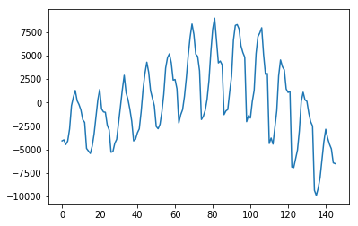

```python
plt.plot(df.index, df.R1Public)
```

*plot the data minus the regression to visualize first remainder behavior*

```python
corrpub = []
for i in range(1, int(len(df)/2)):
    corrpub.append(df['R1Public'].autocorr(lag=i))
print(corrpub.index(max(corrpub)) + 1, max(corrpub))
period = corrpub.index(max(corrpub)) + 1
# cycle length is 12
```

```
12 0.883360049988
```

*find the period of the data by autocorrelation, max autocorrelation comes at intervals of 12*

```python
lag12 = [np.NaN] * period
for i in range(len(df) - 12):
    lag12.append(df['Ordered Public Construction'].iloc[i])
df['lag12pub'] = lag12
```

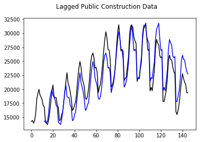

```python
fig, ax = plt.subplots()
fig.suptitle('Lagged Public Construction Data')
ax.plot(df['Ordered Public Construction'], c='k')
ax.plot(df['lag12pub'], c='b')
```

*plot Public Construction data lagged by 1 year*

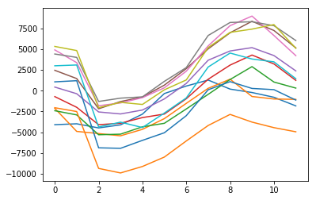

```python
dfYear = pd.DataFrame()
for i in range(int(len(df.index)/period)):
    new = pd.DataFrame({i:df['R1Public'].iloc[i*period:(i+1)*period]})
    new.index = range(0, len(new))
    dfYear = pd.concat([dfYear, new], axis=1)
fig, ax = plt.subplots()
ax.plot(dfYear)
```

*plot each annual pattern simultaneously to view seasonal trends*

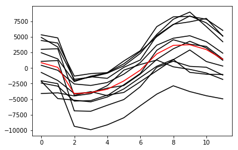

```python
avg = []
for i in range(len(dfYear.index)):
    avg.append(dfYear.iloc[i].mean())

dfYear = pd.concat([dfYear, pd.DataFrame({'avg': avg})], axis=1)
fig, ax = plt.subplots()
for col in dfYear.columns.values:
    if col == 'avg':
        ax.plot(dfYear[col], c='r')
    else:
        ax.plot(dfYear[col], c='k')
```

```python
df['SPublic'] = np.NaN
df['R2Public'] = np.NaN
df['Composite'] = np.NaN
df['R2ErrorPublic'] = np.NaN
S = avg
for i in df.index:
    df.loc[i, 'SPublic'] = S[i%period]
    df.loc[i, 'R2Public'] = df.loc[i, 'R1Public'] - df.loc[i, 'SPublic']
    df.loc[i, 'Composite'] = df.loc[i, 'regress'] + df.loc[i, 'SPublic']
    df.loc[i, 'R2ErrorPublic'] = 100*df.loc[i, 'R2Public'] / df.loc[i,  'Ordered Public Construction']
df.style.format({
    'Ordered Public Construction': '{:,.0f}'.format,
    'regress': '{:,.0f}'.format,
    'R1Public': '{:,.0f}'.format,
    'SPublic': '{:,.0f}'.format,
    'R2Public': '{:,.0f}'.format,
    'Composite': '{:,.0f}'.format,
    'R2ErrorPublic': '{:,.2f}'.format,
})
```

|  | Month | Month-Year | Total Construction | Private Construction | Public Construction | Unnamed: 5 | Unnamed: 6 | Unnamed: 7 | Unnamed: 8 | Unnamed: 9 | Unnamed: 10 | Unnamed: 11 | Unnamed: 12 | Unnamed: 13 | Unnamed: 14 | Unnamed: 15 | Unnamed: 16 | Unnamed: 17 | Unnamed: 18 | Unnamed: 19 | Unnamed: 20 | Unnamed: 21 | Unnamed: 22 | Unnamed: 23 | Ordered Public Construction | Ordered Private Construction | regress | R1Public | lag12pub | … |
| --- | --- | --- | --- | --- | --- | --- | --- | --- | --- | --- | --- | --- | --- | --- | --- | --- | --- | --- | --- | --- | --- | --- | --- | --- | --- | --- | --- | --- | --- | --- |
| 0 | 1 | 2-Jan | 59516 | 45273 | 14243 | nan | nan | nan | nan | nan | nan | nan | nan | nan | nan | nan | nan | nan | nan | nan | nan | nan | nan | nan | 14,243 | 45273 | 18,328 | -4,085 | nan | … |
| 1 | 2 | 2-Feb | 58588 | 44475 | 14113 | nan | nan | nan | nan | nan | nan | nan | nan | nan | nan | nan | nan | nan | nan | nan | nan | nan | nan | nan | 14,404 | 45473 | 18,380 | -3,976 | nan | … |
| 2 | 3 | 2-Mar | 63782 | 49396 | 14386 | nan | nan | nan | nan | nan | nan | nan | nan | nan | nan | nan | nan | nan | nan | nan | nan | nan | nan | nan | 13,959 | 50975 | 18,432 | -4,473 | nan | … |
| 3 | 4 | 2-Apr | 69504 | 53283 | 16221 | nan | nan | nan | nan | nan | nan | nan | nan | nan | nan | nan | nan | nan | nan | nan | nan | nan | nan | nan | 14,380 | 57094 | 18,484 | -4,104 | nan | … |
| 4 | 5 | 2-May | 73384 | 55009 | 18375 | nan | nan | nan | nan | nan | nan | nan | nan | nan | nan | nan | nan | nan | nan | nan | nan | nan | nan | nan | 15,719 | 65339 | 18,536 | -2,817 | nan | … |
| 5 | 6 | 2-Jun | 77182 | 57801 | 19381 | nan | nan | nan | nan | nan | nan | nan | nan | nan | nan | nan | nan | nan | nan | nan | nan | nan | nan | nan | 18,245 | 61161 | 18,588 | -343 | nan | … |
| 6 | 7 | 2-Jul | 78863 | 58494 | 20369 | nan | nan | nan | nan | nan | nan | nan | nan | nan | nan | nan | nan | nan | nan | nan | nan | nan | nan | nan | 19,199 | 58150 | 18,640 | 559 | nan | … |
| 7 | 8 | 2-Aug | 79460 | 57953 | 21507 | nan | nan | nan | nan | nan | nan | nan | nan | nan | nan | nan | nan | nan | nan | nan | nan | nan | nan | nan | 19,971 | 46974 | 18,692 | 1,279 | nan | … |
| 8 | 9 | 2-Sep | 76542 | 55157 | 21385 | nan | nan | nan | nan | nan | nan | nan | nan | nan | nan | nan | nan | nan | nan | nan | nan | nan | nan | nan | 18,936 | 36650 | 18,744 | 192 | nan | … |
| 9 | 10 | 2-Oct | 75710 | 56023 | 19687 | nan | nan | nan | nan | nan | nan | nan | nan | nan | nan | nan | nan | nan | nan | nan | nan | nan | nan | nan | 18,578 | 32377 | 18,796 | -218 | nan | … |
| 10 | 11 | 2-Nov | 71362 | 53552 | 17810 | nan | nan | nan | nan | nan | nan | nan | nan | nan | nan | nan | nan | nan | nan | nan | nan | nan | nan | nan | 18,059 | 37611 | 18,848 | -789 | nan | … |
| 11 | 12 | 2-Dec | 63984 | 48023 | 15961 | nan | nan | nan | nan | nan | nan | nan | nan | nan | nan | nan | nan | nan | nan | nan | nan | nan | nan | nan | 17,074 | 42070 | 18,900 | -1,826 | nan | … |
| 12 | 13 | 3-Jan | 59877 | 45473 | 14404 | nan | nan | nan | nan | nan | nan | nan | nan | nan | nan | nan | nan | nan | nan | nan | nan | nan | nan | nan | 16,834 | 47827 | 18,952 | -2,118 | 14243 | … |
| 13 | 14 | 3-Feb | 58526 | 44620 | 13906 | nan | nan | nan | nan | nan | nan | nan | nan | nan | nan | nan | nan | nan | nan | nan | nan | nan | nan | nan | 14,113 | 44475 | 19,004 | -4,891 | 14404 | … |
| 14 | 15 | 3-Mar | 64506 | 49996 | 14510 | nan | nan | nan | nan | nan | nan | nan | nan | nan | nan | nan | nan | nan | nan | nan | nan | nan | nan | nan | 13,906 | 44620 | 19,056 | -5,150 | 13959 | … |
| 15 | 16 | 3-Apr | 69638 | 53195 | 16444 | nan | nan | nan | nan | nan | nan | nan | nan | nan | nan | nan | nan | nan | nan | nan | nan | nan | nan | nan | 13,689 | 50449 | 19,108 | -5,419 | 14380 | … |
| 16 | 17 | 3-May | 74473 | 56286 | 18187 | nan | nan | nan | nan | nan | nan | nan | nan | nan | nan | nan | nan | nan | nan | nan | nan | nan | nan | nan | 14,517 | 57531 | 19,160 | -4,643 | 15719 | … |
| 17 | 18 | 3-Jun | 80377 | 60076 | 20301 | nan | nan | nan | nan | nan | nan | nan | nan | nan | nan | nan | nan | nan | nan | nan | nan | nan | nan | nan | 15,857 | 65622 | 19,212 | -3,355 | 18245 | … |
| 18 | 19 | 3-Jul | 82971 | 62216 | 20755 | nan | nan | nan | nan | nan | nan | nan | nan | nan | nan | nan | nan | nan | nan | nan | nan | nan | nan | nan | 17,740 | 61437 | 19,264 | -1,524 | 19199 | … |
| 19 | 20 | 3-Aug | 85191 | 63234 | 21957 | nan | nan | nan | nan | nan | nan | nan | nan | nan | nan | nan | nan | nan | nan | nan | nan | nan | nan | nan | 19,602 | 57625 | 19,316 | 286 | 19971 | … |
| 20 | 21 | 3-Sep | 83841 | 61767 | 22075 | nan | nan | nan | nan | nan | nan | nan | nan | nan | nan | nan | nan | nan | nan | nan | nan | nan | nan | nan | 20,748 | 45548 | 19,368 | 1,380 | 18936 | … |
| 21 | 22 | 3-Oct | 83133 | 62813 | 20321 | nan | nan | nan | nan | nan | nan | nan | nan | nan | nan | nan | nan | nan | nan | nan | nan | nan | nan | nan | 18,724 | 35295 | 19,420 | -696 | 18578 | … |
| 22 | 23 | 3-Nov | 77915 | 60115 | 17801 | nan | nan | nan | nan | nan | nan | nan | nan | nan | nan | nan | nan | nan | nan | nan | nan | nan | nan | nan | 18,475 | 32069 | 19,472 | -997 | 18059 | … |
| 23 | 24 | 3-Dec | 71050 | 55584 | 15466 | nan | nan | nan | nan | nan | nan | nan | nan | nan | nan | nan | nan | nan | nan | nan | nan | nan | nan | nan | 18,483 | 37498 | 19,524 | -1,041 | 17074 | … |
| 24 | 25 | 4-Jan | 64934 | 50975 | 13959 | nan | nan | nan | nan | nan | nan | nan | nan | nan | nan | nan | nan | nan | nan | nan | nan | nan | nan | a | 17,171 | 41224 | 19,576 | -2,405 | 16834 | … |
| 25 | 26 | 4-Feb | 64138 | 50449 | 13689 | nan | nan | nan | nan | nan | nan | nan | nan | nan | nan | nan | nan | nan | nan | nan | nan | nan | nan | nan | 16,721 | 46647 | 19,628 | -2,907 | 14113 | … |
| 26 | 27 | 4-Mar | 73238 | 57796 | 15443 | nan | nan | nan | nan | nan | nan | nan | nan | nan | nan | nan | nan | nan | nan | nan | nan | nan | nan | nan | 14,386 | 49396 | 19,680 | -5,294 | 13906 | … |
| 27 | 28 | 4-Apr | 78354 | 61177 | 17177 | nan | nan | nan | nan | nan | nan | nan | nan | nan | nan | nan | nan | nan | nan | nan | nan | nan | nan | nan | 14,510 | 49996 | 19,732 | -5,222 | 13689 | … |
| 28 | 29 | 4-May | 83736 | 65027 | 18709 | nan | nan | nan | nan | nan | nan | nan | nan | nan | nan | nan | nan | nan | nan | nan | nan | nan | nan | nan | 15,443 | 57796 | 19,784 | -4,341 | 14517 | … |
| 29 | 30 | 4-Jun | 89932 | 69039 | 20893 | nan | nan | nan | nan | nan | nan | nan | nan | nan | nan | nan | nan | nan | nan | nan | nan | nan | nan | nan | 15,920 | 65425 | 19,836 | -3,916 | 15857 | … |

[output cut: 116 more lines]

*compute seasonal component, 2nd remainder component, composite for model, and error percentages for model*

```
Text(0,0.5,'Public Construction')
```

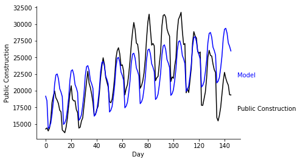

```python
fig, ax = plt.subplots()
ax.text(150, 17000, 'Public Construction', color='k')
ax.text(150, 22000, 'Model', color='b')
ax.plot(df['Ordered Public Construction'], c='k')
ax.plot(df['Composite'], c='b')
ax.spines['top'].set_visible(False)
ax.spines['right'].set_visible(False)
ax.set_xlabel('Day')
ax.set_ylabel('Public Construction')
```

*visualization of model and data to see differences*

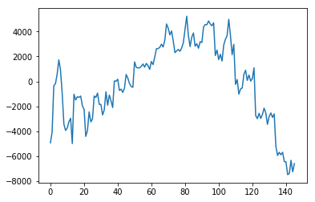

```python
plt.plot(df.R2Public)
```

*display model error for data*

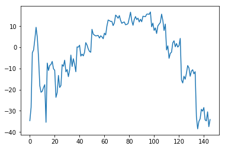

```python
plt.plot(df.R2ErrorPublic)
```

*display model error in percentage for data*

```python
squerrpub = []
for i in df['R2Public']:
    squerrpub.append(i*i)
df['SqErrPublic'] = squerrpub
cumsquerrpub = [squerrpub[0]]
for i in range(1, len(squerrpub)):
    cumsquerrpub.append(sum(squerrpub[:i+1]))
df['CumSqErrPublic'] = cumsquerrpub
```

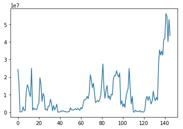

```python
plt.plot(df.SqErrPublic)
```

*plot squared error of model*

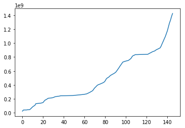

```python
plt.plot(df.CumSqErrPublic)
```

*plot cumulative squared error of model*

*error increases greatly near the end of the data*

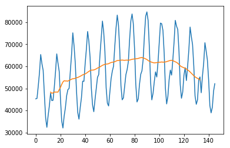

```python
tmp = [np.NaN]*12
opc = list(df['Ordered Private Construction'])
window = 12
for i in range(int(window), len(df) - int(window)):
    tmp.append(sum(opc[i:i+12])/12)
for i in range(12):
    tmp.append(np.NaN)
df['MovAvg'] = tmp
df2 = df['MovAvg'].copy()
df2.dropna(how='any', inplace=True)
fig, ax = plt.subplots()
ax.plot(df['Ordered Private Construction'], label="Private Construction")
ax.plot(df2, label='Moving Average')
```

*plot moving average and private construction data*

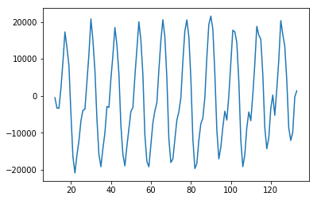

```python
df['R1Priv'] = df['Ordered Private Construction'] - df['MovAvg']
df['SqErrPriv'] = (df['Ordered Private Construction'] - df['MovAvg'])**2
df.style.format({
    'Ordered Private Construction': '{:,.0f}'.format,
    'regress': '{:,.0f}'.format,
    'R2Public': '{:,.0f}'.format
})
fig, ax = plt.subplots()
ax.plot(df['R1Priv'], label="R1Priv")
```

*plot R1 for private construction data*

```
Text(0.5,0.98,'Squared Error')
```

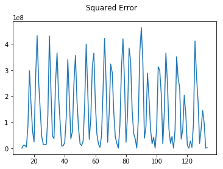

```python
plt.plot(df['SqErrPriv'], label="Squared Error")
plt.suptitle('Squared Error')
```

*plot squared error for private construction data*

```python
corrpriv = []
for i in range(1, int(len(df)/2)):
    corrpriv.append(df['R1Priv'].autocorr(lag=i))
print(corrpriv.index(max(corrpriv)) + 1, max(corrpriv))
period = corrpriv.index(max(corrpriv)) + 1
# cycle length is 12
```

```
12 0.970302824371
```

```python
lag12 = [np.NaN] * period
for i in range(len(df) - 12):
    lag12.append(df['Ordered Public Construction'].iloc[i])
df['lag12priv'] = lag12
```

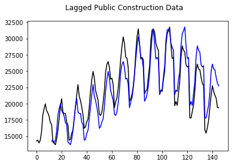

```python
fig, ax = plt.subplots()
fig.suptitle('Lagged Public Construction Data')
ax.plot(df['Ordered Public Construction'], c='k')
ax.plot(df['lag12priv'], c='b')
```

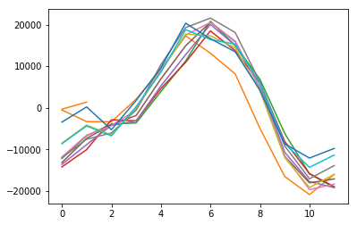

```python
dfYear = pd.DataFrame()
for i in range(int(len(df.index)/period)):
    new = pd.DataFrame({i:df['R1Priv'].iloc[i*period:(i+1)*period]})
    new.index = range(0, len(new))
    dfYear = pd.concat([dfYear, new], axis=1)
fig, ax = plt.subplots()
ax.plot(dfYear)
```

*plot monthly trends for private construction data*

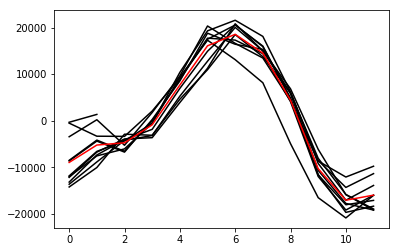

```python
avg = []
for i in range(len(dfYear.index)):
    avg.append(dfYear.iloc[i].mean())

dfYear = pd.concat([dfYear, pd.DataFrame({'avg': avg})], axis=1)
fig, ax = plt.subplots()
for col in dfYear.columns.values:
    if col == 'avg':
        ax.plot(dfYear[col], c='r')
    else:
        ax.plot(dfYear[col], c='k')
```

*plot average monthly trend for private construction data*

```python
df['SPriv'] = np.NaN
df['R2Priv'] = np.NaN
df['CompositePriv'] = np.NaN
df['R2ErrorPriv'] = np.NaN
S = avg
for i in df.index:
    df.loc[i, 'SPriv'] = S[i%period]
    df.loc[i, 'R2Priv'] = df.loc[i, 'R1Priv'] - df.loc[i, 'SPriv']
    df.loc[i, 'CompositePriv'] = df.loc[i, 'MovAvg'] + df.loc[i, 'SPriv']
    df.loc[i, 'R2ErrorPriv'] = 100*df.loc[i, 'R2Priv'] / df.loc[i,  'Ordered Private Construction']
df.style.format({
    'Ordered Private Construction': '{:,.0f}'.format,
    'MovAvg': '{:,.0f}'.format,
    'R1Priv': '{:,.0f}'.format,
    'SPriv': '{:,.0f}'.format,
    'R2Priv': '{:,.0f}'.format,
    'CompositePriv': '{:,.0f}'.format,
    'R2ErrorPriv': '{:,.2f}'.format,
})
```

|  | Month | Month-Year | Total Construction | Private Construction | Public Construction | Unnamed: 5 | Unnamed: 6 | Unnamed: 7 | Unnamed: 8 | Unnamed: 9 | Unnamed: 10 | Unnamed: 11 | Unnamed: 12 | Unnamed: 13 | Unnamed: 14 | Unnamed: 15 | Unnamed: 16 | Unnamed: 17 | Unnamed: 18 | Unnamed: 19 | Unnamed: 20 | Unnamed: 21 | Unnamed: 22 | Unnamed: 23 | Ordered Public Construction | Ordered Private Construction | regress | R1Public | lag12pub | … |
| --- | --- | --- | --- | --- | --- | --- | --- | --- | --- | --- | --- | --- | --- | --- | --- | --- | --- | --- | --- | --- | --- | --- | --- | --- | --- | --- | --- | --- | --- | --- |
| 0 | 1 | 2-Jan | 59516 | 45273 | 14243 | nan | nan | nan | nan | nan | nan | nan | nan | nan | nan | nan | nan | nan | nan | nan | nan | nan | nan | nan | 14243 | 45,273 | 18327.9 | -4084.94 | nan | … |
| 1 | 2 | 2-Feb | 58588 | 44475 | 14113 | nan | nan | nan | nan | nan | nan | nan | nan | nan | nan | nan | nan | nan | nan | nan | nan | nan | nan | nan | 14404 | 45,473 | 18379.9 | -3975.95 | nan | … |
| 2 | 3 | 2-Mar | 63782 | 49396 | 14386 | nan | nan | nan | nan | nan | nan | nan | nan | nan | nan | nan | nan | nan | nan | nan | nan | nan | nan | nan | 13959 | 50,975 | 18432 | -4472.96 | nan | … |
| 3 | 4 | 2-Apr | 69504 | 53283 | 16221 | nan | nan | nan | nan | nan | nan | nan | nan | nan | nan | nan | nan | nan | nan | nan | nan | nan | nan | nan | 14380 | 57,094 | 18484 | -4103.97 | nan | … |
| 4 | 5 | 2-May | 73384 | 55009 | 18375 | nan | nan | nan | nan | nan | nan | nan | nan | nan | nan | nan | nan | nan | nan | nan | nan | nan | nan | nan | 15719 | 65,339 | 18536 | -2816.97 | nan | … |
| 5 | 6 | 2-Jun | 77182 | 57801 | 19381 | nan | nan | nan | nan | nan | nan | nan | nan | nan | nan | nan | nan | nan | nan | nan | nan | nan | nan | nan | 18245 | 61,161 | 18588 | -342.983 | nan | … |
| 6 | 7 | 2-Jul | 78863 | 58494 | 20369 | nan | nan | nan | nan | nan | nan | nan | nan | nan | nan | nan | nan | nan | nan | nan | nan | nan | nan | nan | 19199 | 58,150 | 18640 | 559.009 | nan | … |
| 7 | 8 | 2-Aug | 79460 | 57953 | 21507 | nan | nan | nan | nan | nan | nan | nan | nan | nan | nan | nan | nan | nan | nan | nan | nan | nan | nan | nan | 19971 | 46,974 | 18692 | 1279 | nan | … |
| 8 | 9 | 2-Sep | 76542 | 55157 | 21385 | nan | nan | nan | nan | nan | nan | nan | nan | nan | nan | nan | nan | nan | nan | nan | nan | nan | nan | nan | 18936 | 36,650 | 18744 | 191.991 | nan | … |
| 9 | 10 | 2-Oct | 75710 | 56023 | 19687 | nan | nan | nan | nan | nan | nan | nan | nan | nan | nan | nan | nan | nan | nan | nan | nan | nan | nan | nan | 18578 | 32,377 | 18796 | -218.017 | nan | … |
| 10 | 11 | 2-Nov | 71362 | 53552 | 17810 | nan | nan | nan | nan | nan | nan | nan | nan | nan | nan | nan | nan | nan | nan | nan | nan | nan | nan | nan | 18059 | 37,611 | 18848 | -789.026 | nan | … |
| 11 | 12 | 2-Dec | 63984 | 48023 | 15961 | nan | nan | nan | nan | nan | nan | nan | nan | nan | nan | nan | nan | nan | nan | nan | nan | nan | nan | nan | 17074 | 42,070 | 18900 | -1826.03 | nan | … |
| 12 | 13 | 3-Jan | 59877 | 45473 | 14404 | nan | nan | nan | nan | nan | nan | nan | nan | nan | nan | nan | nan | nan | nan | nan | nan | nan | nan | nan | 16834 | 47,827 | 18952 | -2118.04 | 14243 | … |
| 13 | 14 | 3-Feb | 58526 | 44620 | 13906 | nan | nan | nan | nan | nan | nan | nan | nan | nan | nan | nan | nan | nan | nan | nan | nan | nan | nan | nan | 14113 | 44,475 | 19004.1 | -4891.05 | 14404 | … |
| 14 | 15 | 3-Mar | 64506 | 49996 | 14510 | nan | nan | nan | nan | nan | nan | nan | nan | nan | nan | nan | nan | nan | nan | nan | nan | nan | nan | nan | 13906 | 44,620 | 19056.1 | -5150.06 | 13959 | … |
| 15 | 16 | 3-Apr | 69638 | 53195 | 16444 | nan | nan | nan | nan | nan | nan | nan | nan | nan | nan | nan | nan | nan | nan | nan | nan | nan | nan | nan | 13689 | 50,449 | 19108.1 | -5419.07 | 14380 | … |
| 16 | 17 | 3-May | 74473 | 56286 | 18187 | nan | nan | nan | nan | nan | nan | nan | nan | nan | nan | nan | nan | nan | nan | nan | nan | nan | nan | nan | 14517 | 57,531 | 19160.1 | -4643.08 | 15719 | … |
| 17 | 18 | 3-Jun | 80377 | 60076 | 20301 | nan | nan | nan | nan | nan | nan | nan | nan | nan | nan | nan | nan | nan | nan | nan | nan | nan | nan | nan | 15857 | 65,622 | 19212.1 | -3355.09 | 18245 | … |
| 18 | 19 | 3-Jul | 82971 | 62216 | 20755 | nan | nan | nan | nan | nan | nan | nan | nan | nan | nan | nan | nan | nan | nan | nan | nan | nan | nan | nan | 17740 | 61,437 | 19264.1 | -1524.09 | 19199 | … |
| 19 | 20 | 3-Aug | 85191 | 63234 | 21957 | nan | nan | nan | nan | nan | nan | nan | nan | nan | nan | nan | nan | nan | nan | nan | nan | nan | nan | nan | 19602 | 57,625 | 19316.1 | 285.897 | 19971 | … |
| 20 | 21 | 3-Sep | 83841 | 61767 | 22075 | nan | nan | nan | nan | nan | nan | nan | nan | nan | nan | nan | nan | nan | nan | nan | nan | nan | nan | nan | 20748 | 45,548 | 19368.1 | 1379.89 | 18936 | … |
| 21 | 22 | 3-Oct | 83133 | 62813 | 20321 | nan | nan | nan | nan | nan | nan | nan | nan | nan | nan | nan | nan | nan | nan | nan | nan | nan | nan | nan | 18724 | 35,295 | 19420.1 | -696.12 | 18578 | … |
| 22 | 23 | 3-Nov | 77915 | 60115 | 17801 | nan | nan | nan | nan | nan | nan | nan | nan | nan | nan | nan | nan | nan | nan | nan | nan | nan | nan | nan | 18475 | 32,069 | 19472.1 | -997.129 | 18059 | … |
| 23 | 24 | 3-Dec | 71050 | 55584 | 15466 | nan | nan | nan | nan | nan | nan | nan | nan | nan | nan | nan | nan | nan | nan | nan | nan | nan | nan | nan | 18483 | 37,498 | 19524.1 | -1041.14 | 17074 | … |
| 24 | 25 | 4-Jan | 64934 | 50975 | 13959 | nan | nan | nan | nan | nan | nan | nan | nan | nan | nan | nan | nan | nan | nan | nan | nan | nan | nan | a | 17171 | 41,224 | 19576.1 | -2405.15 | 16834 | … |
| 25 | 26 | 4-Feb | 64138 | 50449 | 13689 | nan | nan | nan | nan | nan | nan | nan | nan | nan | nan | nan | nan | nan | nan | nan | nan | nan | nan | nan | 16721 | 46,647 | 19628.2 | -2907.15 | 14113 | … |
| 26 | 27 | 4-Mar | 73238 | 57796 | 15443 | nan | nan | nan | nan | nan | nan | nan | nan | nan | nan | nan | nan | nan | nan | nan | nan | nan | nan | nan | 14386 | 49,396 | 19680.2 | -5294.16 | 13906 | … |
| 27 | 28 | 4-Apr | 78354 | 61177 | 17177 | nan | nan | nan | nan | nan | nan | nan | nan | nan | nan | nan | nan | nan | nan | nan | nan | nan | nan | nan | 14510 | 49,996 | 19732.2 | -5222.17 | 13689 | … |
| 28 | 29 | 4-May | 83736 | 65027 | 18709 | nan | nan | nan | nan | nan | nan | nan | nan | nan | nan | nan | nan | nan | nan | nan | nan | nan | nan | nan | 15443 | 57,796 | 19784.2 | -4341.18 | 14517 | … |
| 29 | 30 | 4-Jun | 89932 | 69039 | 20893 | nan | nan | nan | nan | nan | nan | nan | nan | nan | nan | nan | nan | nan | nan | nan | nan | nan | nan | nan | 15920 | 65,425 | 19836.2 | -3916.19 | 15857 | … |

[output cut: 116 more lines]

*compute seasonal component, 2nd remainder component, composite for model, and error percentages for model*

```
Text(0,0.5,'Private Construction')
```

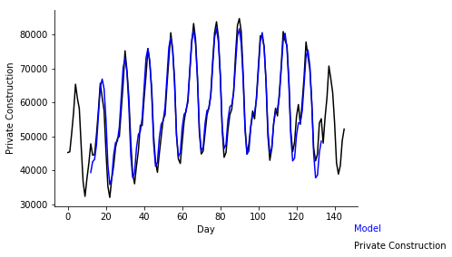

```python
fig, ax = plt.subplots()
ax.text(150, 17000, 'Private Construction', color='k')
ax.text(150, 22000, 'Model', color='b')
ax.plot(df['Ordered Private Construction'], c='k')
ax.plot(df['CompositePriv'], c='b')
ax.spines['top'].set_visible(False)
ax.spines['right'].set_visible(False)
ax.set_xlabel('Day')
ax.set_ylabel('Private Construction')
```

*visualization of model and data to see differences*

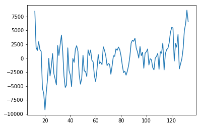

```python
plt.plot(df.R2Priv)
```

*plot model error data*

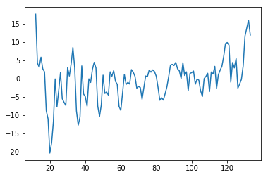

```python
plt.plot(df.R2ErrorPriv)
```

*plot model error in percentage*

```python
squerrpriv = []
for i in df['R2Priv']:
    squerrpriv.append(i*i)
df['SqErrPriv'] = squerrpriv
cumsquerrpriv = [np.NaN]*12
for i in range(12, len(squerrpriv) - 12):
    cumsquerrpriv.append(sum(squerrpriv[12:i+1]))
for i in range(12):
    cumsquerrpriv.append(np.NaN)
df['CumSqErrPriv'] = cumsquerrpriv
```

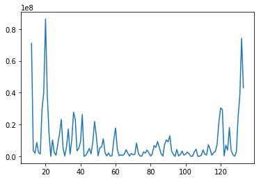

```python
plt.plot(df.SqErrPriv)
```

*plot squared error of model*

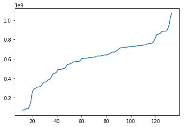

```python
plt.plot(df.CumSqErrPriv)
```

*plot cumulative squared error of model*